# **Capstone Project- Lung Opacity Detection**

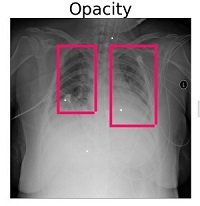

**Table of Contents:**

1. Load Datasets
2. Data Wrangling/EDA
3. Overview of DICOM files and medical images
4. Visualization of DICOM images
5. Modelling
6. Transfer Learning
7. Hyper Parameter Tuning
8. Plot History
9. Save Model weights
10. Predict Test images

```python
from google.colab import drive
drive.mount('/content/drive')
```

```python
import pandas as pd
import numpy as np
import matplotlib
import matplotlib.pyplot as plt
from tqdm import tqdm_notebook
from matplotlib.patches import Rectangle
import seaborn as sns
!pip install pydicom
import pydicom as dcm
%matplotlib inline
IS_LOCAL = False
import os
if(IS_LOCAL):
    PATH="/content/drive/My Drive/"
else:
    PATH="/content/drive/My Drive/GL_Capstone"
print(os.listdir(PATH))
```

```
     |████████████████████████████████| 35.5MB 116kB/s
['GCP Credits Request Link - RSNA.txt', 'stage_2_sample_submission.csv', '.ipynb_checkpoints', 'stage_2_train_labels.csv', 'stage_2_detailed_class_info.csv', 'stage_2_test_images.zip', 'stage_2_train_images.zip', 'stage_2_test_images', 'stage_2_train_images']
```

# **1.Load Datasets**

```python
detailclassinfo_df = pd.read_csv(PATH+ "/stage_2_detailed_class_info.csv")
trainlabels_df = pd.read_csv(PATH+ "/stage_2_train_labels.csv")
```

```python
detailclassinfo_df.head()
```

|  | patientId | class |
| --- | --- | --- |
| 0 | 0004cfab-14fd-4e49-80ba-63a80b6bddd6 | No Lung Opacity / Not Normal |
| 1 | 00313ee0-9eaa-42f4-b0ab-c148ed3241cd | No Lung Opacity / Not Normal |
| 2 | 00322d4d-1c29-4943-afc9-b6754be640eb | No Lung Opacity / Not Normal |
| 3 | 003d8fa0-6bf1-40ed-b54c-ac657f8495c5 | Normal |
| 4 | 00436515-870c-4b36-a041-de91049b9ab4 | Lung Opacity |

```python
trainlabels_df.head()
```

|  | patientId | x | y | width | height | Target |
| --- | --- | --- | --- | --- | --- | --- |
| 0 | 0004cfab-14fd-4e49-80ba-63a80b6bddd6 | NaN | NaN | NaN | NaN | 0 |
| 1 | 00313ee0-9eaa-42f4-b0ab-c148ed3241cd | NaN | NaN | NaN | NaN | 0 |
| 2 | 00322d4d-1c29-4943-afc9-b6754be640eb | NaN | NaN | NaN | NaN | 0 |
| 3 | 003d8fa0-6bf1-40ed-b54c-ac657f8495c5 | NaN | NaN | NaN | NaN | 0 |
| 4 | 00436515-870c-4b36-a041-de91049b9ab4 | 264.0 | 152.0 | 213.0 | 379.0 | 1 |

```python
print(trainlabels_df.iloc[0])
```

```
patientId    0004cfab-14fd-4e49-80ba-63a80b6bddd6
x                                             NaN
y                                             NaN
width                                         NaN
height                                        NaN
Target                                          0
Name: 0, dtype: object
```

```python
print('Shape of Detailed Class information: {}'.format(detailclassinfo_df.shape))
print('Shape of Trained Labels: {}'.format(trainlabels_df.shape))
```

```
Shape of Detailed Class information: (30227, 2)
Shape of Trained Labels: (30227, 6)
```

# **2. Data Wrangling/EDA**

**Merge data sets**

```python
merge_train_df = trainlabels_df.merge(detailclassinfo_df, left_on='patientId', right_on='patientId', how='inner')
merge_train_df.sample(5)
```

|  | patientId | x | y | width | height | Target | class |
| --- | --- | --- | --- | --- | --- | --- | --- |
| 21479 | a64bea19-d9c9-41fa-b714-d834b43846b8 | NaN | NaN | NaN | NaN | 0 | No Lung Opacity / Not Normal |
| 19697 | 9a041c2c-0bf9-4978-8720-58be5d7e71fe | NaN | NaN | NaN | NaN | 0 | No Lung Opacity / Not Normal |
| 25395 | b9590757-7c68-4dc8-9d64-eb59f652b0c9 | NaN | NaN | NaN | NaN | 0 | Normal |
| 36904 | 220e0278-363d-431b-8094-1e28085ddb0f | 644.0 | 345.0 | 192.0 | 337.0 | 1 | Lung Opacity |
| 33600 | f0646657-7174-461b-9ab4-07242c759384 | 689.0 | 403.0 | 212.0 | 462.0 | 1 | Lung Opacity |

```python
merge_train_df = merge_train_df. drop_duplicates()
merge_train_df.shape
```

```
(30227, 7)
```

**Summary on the values, types and null values**

```python
merge_train_df.isnull().sum()
```

```
patientId        0
x            20672
y            20672
width        20672
height       20672
Target           0
class            0
dtype: int64
```

**Inference**: Bounding box parameters x, y, width, height are having **20672** NaN values.

**Distribution of classes**

```python
detailclassinfo_df.groupby(["class"]).count().transpose().style.background_gradient(cmap='Wistia',axis=1)
```

| class | Lung Opacity | No Lung Opacity / Not Normal | Normal |
| --- | --- | --- | --- |
| patientId | 9555 | 11821 | 8851 |

```python
merge_train_df.groupby(["class"]).count().transpose().style.background_gradient(cmap='Wistia',axis=1)
```

| class | Lung Opacity | No Lung Opacity / Not Normal | Normal |
| --- | --- | --- | --- |
| patientId | 9555 | 11821 | 8851 |
| x | 9555 | 0 | 0 |
| y | 9555 | 0 | 0 |
| width | 9555 | 0 | 0 |
| height | 9555 | 0 | 0 |
| Target | 9555 | 11821 | 8851 |

**Insight**: There are 9555 patients in the category 'Lung Opacity', 11821 in 'No Lung Opacity / Not Normal' category and 8851 are in Normal category.

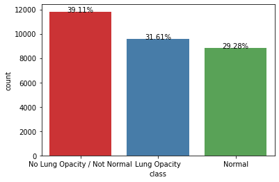

```python
f, ax = plt.subplots(1,1, figsize=(6,4))
total = float(len(merge_train_df))
sns.countplot(merge_train_df['class'],order = merge_train_df['class'].value_counts().index, palette='Set1')
for p in ax.patches:
    height = p.get_height()
    ax.text(p.get_x()+p.get_width()/2.,
            height + 3,
            '{:1.2f}%'.format(100*height/total),
            ha="center")
plt.show()
```

**Insight**: The classes "No Lung Opacity / Not Normal", "Lung Opacity" and "Normal" are in the proportions of 39%, 32% and 29% respectively

**Distribution of Labels (Positive and Negative)**

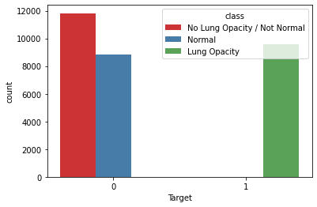

```python
f, ax = plt.subplots(1,1, figsize=(6,4))
sns.countplot(x = "Target", data= merge_train_df, hue="class", palette='Set1')
```

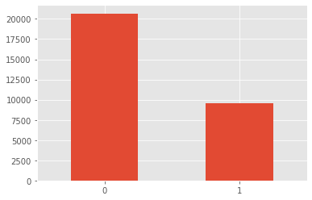

```python
plt.style.use('ggplot')
f, ax = plt.subplots(1,1, figsize=(6,4))
totale = float(len(merge_train_df))
pd.value_counts(merge_train_df["Target"]).plot(kind='bar', position=0.5, rot=0)
```

```python
merge_train_df.groupby(["Target"]).count()
```

| Target | patientId | x | y | width | height | class |
| --- | --- | --- | --- | --- | --- | --- |
| 0 | 20672 | 0 | 0 | 0 | 0 | 20672 |
| 1 | 9555 | 9555 | 9555 | 9555 | 9555 | 9555 |

```python
# Number of positive targets
print(round((9555 / (9555 + 20672)) * 100, 2), '% of the patients are positive')
```

```
31.61 % of the patients are positive
```

**Insight**:

1. Patients with Target = 0 (no pathology detected) are either of class: Normal or class: No Lung Opacity / Not Normal don't have bounding box coordinates (x, y, w, h) parameters.
2. 31.61 % of the patients are positive

```python
opacity_df = merge_train_df[merge_train_df['Target']==1]
opacity_df.head()
```

|  | patientId | x | y | width | height | Target | class |
| --- | --- | --- | --- | --- | --- | --- | --- |
| 4 | 00436515-870c-4b36-a041-de91049b9ab4 | 264.0 | 152.0 | 213.0 | 379.0 | 1 | Lung Opacity |
| 6 | 00436515-870c-4b36-a041-de91049b9ab4 | 562.0 | 152.0 | 256.0 | 453.0 | 1 | Lung Opacity |
| 10 | 00704310-78a8-4b38-8475-49f4573b2dbb | 323.0 | 577.0 | 160.0 | 104.0 | 1 | Lung Opacity |
| 12 | 00704310-78a8-4b38-8475-49f4573b2dbb | 695.0 | 575.0 | 162.0 | 137.0 | 1 | Lung Opacity |
| 18 | 00aecb01-a116-45a2-956c-08d2fa55433f | 288.0 | 322.0 | 94.0 | 135.0 | 1 | Lung Opacity |

```python
opacity_df.shape
```

```
(9555, 7)
```

**Fill NaN values using KNN Imputation method**

```python
merge_train_df.sample(5)
```

|  | patientId | x | y | width | height | Target | class |
| --- | --- | --- | --- | --- | --- | --- | --- |
| 16703 | 86d81c2a-dbcb-4fc5-aba5-023108f1ef1e | NaN | NaN | NaN | NaN | 0 | Normal |
| 660 | 07f78db5-7d9a-4ba0-a00f-02c36953020f | 170.0 | 356.0 | 358.0 | 519.0 | 1 | Lung Opacity |
| 15816 | 80e23d5e-c9f9-4f89-ab8f-d7b1a48efd84 | 548.0 | 184.0 | 320.0 | 533.0 | 1 | Lung Opacity |
| 35543 | fdca8fb0-7118-4143-b87d-cc42bb8b4f5a | NaN | NaN | NaN | NaN | 0 | No Lung Opacity / Not Normal |
| 6344 | 3f167f68-6cde-478d-8e78-9ae22529c22f | 305.0 | 488.0 | 124.0 | 207.0 | 1 | Lung Opacity |

```python
merge_bb_df = merge_train_df.drop(columns = ["patientId", "class"])
merge_bb_df.sample(5)
```

|  | x | y | width | height | Target |
| --- | --- | --- | --- | --- | --- |
| 32909 | 324.0 | 589.0 | 113.0 | 95.0 | 1 |
| 6737 | 550.0 | 237.0 | 331.0 | 461.0 | 1 |
| 22739 | NaN | NaN | NaN | NaN | 0 |
| 23056 | 205.0 | 606.0 | 205.0 | 202.0 | 1 |
| 134 | 698.0 | 288.0 | 226.0 | 311.0 | 1 |

```python
opacity_bb_df = merge_bb_df[(merge_bb_df['Target']== 1)]
opacity_bb_df
```

|  | x | y | width | height | Target |
| --- | --- | --- | --- | --- | --- |
| 4 | 264.0 | 152.0 | 213.0 | 379.0 | 1 |
| 6 | 562.0 | 152.0 | 256.0 | 453.0 | 1 |
| 10 | 323.0 | 577.0 | 160.0 | 104.0 | 1 |
| 12 | 695.0 | 575.0 | 162.0 | 137.0 | 1 |
| 18 | 288.0 | 322.0 | 94.0 | 135.0 | 1 |
| ... | ... | ... | ... | ... | ... |
| 37617 | 316.0 | 504.0 | 179.0 | 273.0 | 1 |
| 37619 | 609.0 | 464.0 | 240.0 | 284.0 | 1 |
| 37621 | 185.0 | 298.0 | 228.0 | 379.0 | 1 |
| 37625 | 570.0 | 393.0 | 261.0 | 345.0 | 1 |
| 37627 | 233.0 | 424.0 | 201.0 | 356.0 | 1 |

9555 rows × 5 columns

```python
from sklearn.impute import KNNImputer
imputer = KNNImputer(n_neighbors=2)
opacity_bb_impute_df = imputer.fit_transform(opacity_bb_df)
```

```python
opacity_bb_impute_df
```

```
array([[264., 152., 213., 379.,   1.],
       [562., 152., 256., 453.,   1.],
       [323., 577., 160., 104.,   1.],
       ...,
       [185., 298., 228., 379.,   1.],
       [570., 393., 261., 345.,   1.],
       [233., 424., 201., 356.,   1.]])
```

```python
opacity_bb_impute_final = pd.DataFrame(data=opacity_bb_impute_df, columns=["x", "y", "width", "height", "Target"])
opacity_bb_impute_final.head(5)
```

|  | x | y | width | height | Target |
| --- | --- | --- | --- | --- | --- |
| 0 | 264.0 | 152.0 | 213.0 | 379.0 | 1.0 |
| 1 | 562.0 | 152.0 | 256.0 | 453.0 | 1.0 |
| 2 | 323.0 | 577.0 | 160.0 | 104.0 | 1.0 |
| 3 | 695.0 | 575.0 | 162.0 | 137.0 | 1.0 |
| 4 | 288.0 | 322.0 | 94.0 | 135.0 | 1.0 |

```python
opacity_bb_impute_final["Target"] = opacity_bb_impute_final["Target"].astype('int64')
```

```python
opacity_bb_impute_final.head(5)
```

|  | x | y | width | height | Target |
| --- | --- | --- | --- | --- | --- |
| 0 | 264.0 | 152.0 | 213.0 | 379.0 | 1 |
| 1 | 562.0 | 152.0 | 256.0 | 453.0 | 1 |
| 2 | 323.0 | 577.0 | 160.0 | 104.0 | 1 |
| 3 | 695.0 | 575.0 | 162.0 | 137.0 | 1 |
| 4 | 288.0 | 322.0 | 94.0 | 135.0 | 1 |

```python
opacity_bb_impute_final.info()
```

```
<class 'pandas.core.frame.DataFrame'>
RangeIndex: 9555 entries, 0 to 9554
Data columns (total 5 columns):
 #   Column  Non-Null Count  Dtype
---  ------  --------------  -----
 0   x       9555 non-null   float64
 1   y       9555 non-null   float64
 2   width   9555 non-null   float64
 3   height  9555 non-null   float64
 4   Target  9555 non-null   int64
dtypes: float64(4), int64(1)
memory usage: 373.4 KB
```

```python
opacity_bb_impute_final.shape
```

```
(9555, 5)
```

**Data Distribution of bounding box parameters**

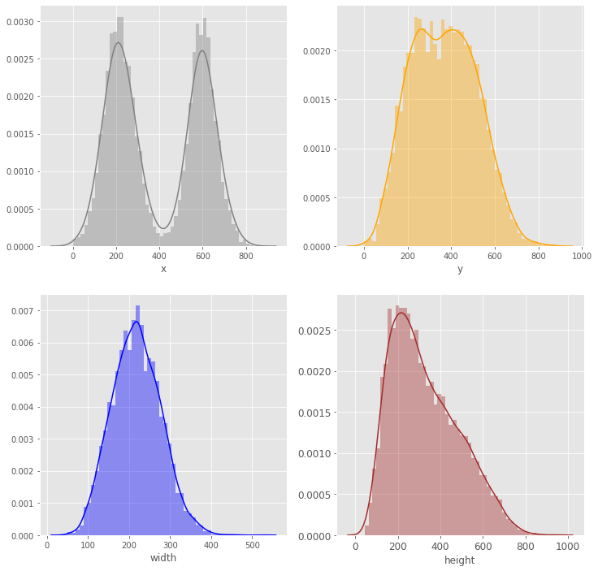

```python
fig, ax = plt.subplots(2,2,figsize=(12,12))
sns.distplot(opacity_bb_impute_final['x'],kde=True,bins=50, color="grey", ax=ax[0,0])
sns.distplot(opacity_bb_impute_final['y'],kde=True,bins=50, color="orange", ax=ax[0,1])
sns.distplot(opacity_bb_impute_final['width'],kde=True,bins=50, color="blue", ax=ax[1,0])
sns.distplot(opacity_bb_impute_final['height'],kde=True,bins=50, color="brown", ax=ax[1,1])
locs, labels = plt.xticks()
plt.tick_params(axis='both', which='major', labelsize=12)
plt.show()
```

**Correlation**

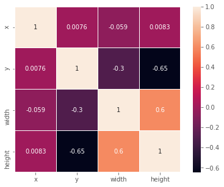

```python
# Correlation
plt.figure(figsize=(7,5))
sns.heatmap(opacity_bb_impute_final.drop(columns = ["Target"]).corr(),linewidths=0.1,vmax=1.0,
            square=True,  linecolor='white', annot=True)
plt.show()
```

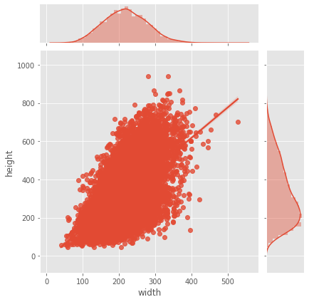

```python
sns.jointplot(x = 'width', y = 'height', data = opacity_bb_impute_final, kind="reg")
```

**Inference**: There is a strong correlation between width and height variables.

**Lung Opacity representation of 2000 samples**

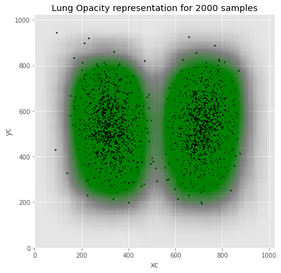

```python
fig, ax = plt.subplots(1,1,figsize=(7,7))
target_sample = opacity_bb_impute_final.sample(2000)
target_sample['xc'] = target_sample['x'] + target_sample['width'] / 2
target_sample['yc'] = target_sample['y'] + target_sample['height'] / 2
plt.title("Lung Opacity representation for 2000 samples")
target_sample.plot.scatter(x='xc', y='yc', xlim=(0,1024), ylim=(0,1024), ax=ax, alpha=0.8, marker=".", color="black")
for i, crt_sample in target_sample.iterrows():
    ax.add_patch(Rectangle(xy=(crt_sample['x'], crt_sample['y']),
                width=crt_sample['width'],height=crt_sample['height'],alpha=3.5e-3, color="green"))
plt.show()
```

# **3. Overview of DICOM files and medical images**

Medical images are stored in DICOM file format (.DCM). In python pydicom library is used to manipulate these kind of files.

**Load DICOM data**

```python
patientId = trainlabels_df['patientId'][0]
dcm_file = '/content/drive/My Drive/GL_Capstone/stage_2_train_images/%s.dcm' % patientId
dcm_data = dcm.read_file(dcm_file)
print(dcm_data)
```

```
Dataset.file_meta -------------------------------
(0002, 0000) File Meta Information Group Length  UL: 202
(0002, 0001) File Meta Information Version       OB: b'\x00\x01'
(0002, 0002) Media Storage SOP Class UID         UI: Secondary Capture Image Storage
(0002, 0003) Media Storage SOP Instance UID      UI: 1.2.276.0.7230010.3.1.4.8323329.28530.1517874485.775526
(0002, 0010) Transfer Syntax UID                 UI: JPEG Baseline (Process 1)
(0002, 0012) Implementation Class UID            UI: 1.2.276.0.7230010.3.0.3.6.0
(0002, 0013) Implementation Version Name         SH: 'OFFIS_DCMTK_360'
-------------------------------------------------
(0008, 0005) Specific Character Set              CS: 'ISO_IR 100'
(0008, 0016) SOP Class UID                       UI: Secondary Capture Image Storage
(0008, 0018) SOP Instance UID                    UI: 1.2.276.0.7230010.3.1.4.8323329.28530.1517874485.775526
(0008, 0020) Study Date                          DA: '19010101'
(0008, 0030) Study Time                          TM: '000000.00'
(0008, 0050) Accession Number                    SH: ''
(0008, 0060) Modality                            CS: 'CR'
(0008, 0064) Conversion Type                     CS: 'WSD'
(0008, 0090) Referring Physician's Name          PN: ''
(0008, 103e) Series Description                  LO: 'view: PA'
(0010, 0010) Patient's Name                      PN: '0004cfab-14fd-4e49-80ba-63a80b6bddd6'
(0010, 0020) Patient ID                          LO: '0004cfab-14fd-4e49-80ba-63a80b6bddd6'
(0010, 0030) Patient's Birth Date                DA: ''
(0010, 0040) Patient's Sex                       CS: 'F'
(0010, 1010) Patient's Age                       AS: '51'
(0018, 0015) Body Part Examined                  CS: 'CHEST'
(0018, 5101) View Position                       CS: 'PA'
(0020, 000d) Study Instance UID                  UI: 1.2.276.0.7230010.3.1.2.8323329.28530.1517874485.775525
(0020, 000e) Series Instance UID                 UI: 1.2.276.0.7230010.3.1.3.8323329.28530.1517874485.775524
(0020, 0010) Study ID                            SH: ''
(0020, 0011) Series Number                       IS: "1"
(0020, 0013) Instance Number                     IS: "1"
(0020, 0020) Patient Orientation                 CS: ''
(0028, 0002) Samples per Pixel                   US: 1
(0028, 0004) Photometric Interpretation          CS: 'MONOCHROME2'
(0028, 0010) Rows                                US: 1024
(0028, 0011) Columns                             US: 1024
(0028, 0030) Pixel Spacing                       DS: [0.14300000000000002, 0.14300000000000002]
(0028, 0100) Bits Allocated                      US: 8
(0028, 0101) Bits Stored                         US: 8
(0028, 0102) High Bit                            US: 7
(0028, 0103) Pixel Representation                US: 0
(0028, 2110) Lossy Image Compression             CS: '01'
(0028, 2114) Lossy Image Compression Method      CS: 'ISO_10918_1'
(7fe0, 0010) Pixel Data                          OB: Array of 142006 elements
```

```python
im = dcm_data.pixel_array
print(type(im))
print(im.dtype)
print(im.shape)
```

```
<class 'numpy.ndarray'>
uint8
(1024, 1024)
```

**Visualize sample image**

```
(-0.5, 1023.5, 1023.5, -0.5)
```

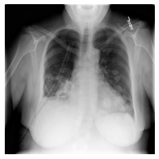

```python
import pylab
pylab.imshow(im, cmap=pylab.cm.gist_gray)
pylab.axis('off')
```

# **4. Visualization of DICOM images**

**Plotting bounding boxes around images**

```python
def parse_data(df):
    """
    Method to read a CSV file (Pandas dataframe) and parse the
    data into the following nested dictionary:

      parsed = {

        'patientId-00': {
            'dicom': path/to/dicom/file,
            'label': either 0 or 1 for normal or pnuemonia,
            'boxes': list of box(es)
        },
        'patientId-01': {
            'dicom': path/to/dicom/file,
            'label': either 0 or 1 for normal or pnuemonia,
            'boxes': list of box(es)
        }, ...

      }

    """
    # --- Define lambda to extract coords in list [y, x, height, width]
    extract_box = lambda row: [row['y'], row['x'], row['height'], row['width']]

    parsed = {}
    for n, row in df.iterrows():
        # --- Initialize patient entry into parsed
        pid = row['patientId']
        if pid not in parsed:
            parsed[pid] = {
                'dicom': '/content/drive/My Drive/GL_Capstone/stage_2_train_images/%s.dcm' % pid,
                'label': row['Target'],
                'boxes': []}

        # --- Add box if opacity is present
        if parsed[pid]['label'] == 1:
            parsed[pid]['boxes'].append(extract_box(row))

    return parsed

parsed = parse_data(trainlabels_df)

def draw(data):
    """
    Method to draw single patient with bounding box(es) if present

    """
    # --- Open DICOM file
    d = dcm.read_file(data['dicom'])
    im = d.pixel_array

    # --- Convert from single-channel grayscale to 3-channel RGB
    im = np.stack([im] * 3, axis=2)

    # --- Add boxes with random color if present
    for box in data['boxes']:
        #rgb = np.floor(np.random.rand(3) * 256).astype('int')
        rgb = [255,10,100] # Just use magenta
        im = overlay_box(im=im, box=box, rgb=rgb, stroke=15)

    plt.imshow(im, cmap=plt.cm.gist_gray)
    plt.axis('off')

def overlay_box(im, box, rgb, stroke=2):
    """
    Method to overlay single box on image

    """
    # --- Convert coordinates to integers
    box = [int(b) for b in box]

    # --- Extract coordinates
    y1, x1, height, width = box
    y2 = y1 + height
    x2 = x1 + width

    im[y1:y1 + stroke, x1:x2] = rgb
    im[y2:y2 + stroke, x1:x2] = rgb
    im[y1:y2, x1:x1 + stroke] = rgb
    im[y1:y2, x2:x2 + stroke] = rgb

    return im
```

**Visualize Train Labels dataset images**

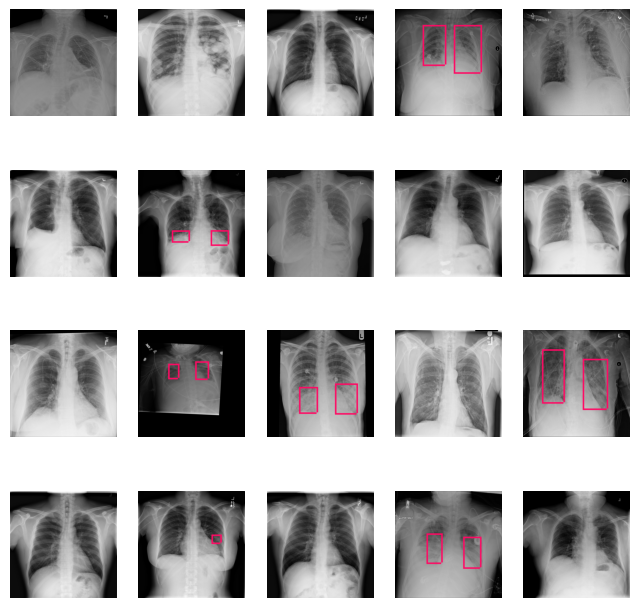

```python
plt.style.use('default')
fig=plt.figure(figsize=(8, 8))
columns = 5; rows = 4
for i in range(1, columns*rows +1):
    fig.add_subplot(rows, columns, i)
    draw(parsed[trainlabels_df['patientId'].unique()[i]])
    fig.add_subplot
```

**Visualize Detail Class dataset images**

```python
opacity = detailclassinfo_df \
    .loc[detailclassinfo_df['class'] == 'Lung Opacity'] \
    .reset_index()
```

```python
not_normal = detailclassinfo_df \
    .loc[detailclassinfo_df['class'] == 'No Lung Opacity / Not Normal'] \
    .reset_index()
```

```python
normal = detailclassinfo_df \
    .loc[detailclassinfo_df['class'] == 'Normal'] \
    .reset_index()
```

**1. Lung Opacity Samples**

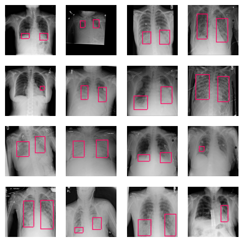

```python
plt.style.use('default')
fig=plt.figure(figsize=(6, 6))
columns = 4; rows = 4
for i in range(1, columns*rows +1):
    fig.add_subplot(rows, columns, i)
    draw(parsed[opacity['patientId'].unique()[i]])
```

**2. Normal Samples**

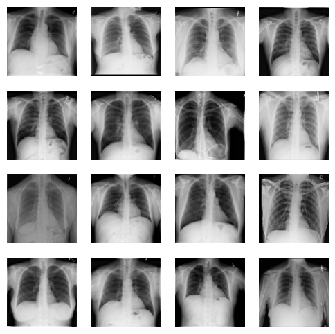

```python
plt.style.use('default')
fig=plt.figure(figsize=(6, 6))
columns = 4; rows = 4
for i in range(1, columns*rows +1):
    fig.add_subplot(rows, columns, i)
    draw(parsed[normal['patientId'].unique()[i]])
```

**3. No Lung Opacity/Not Normal Samples**

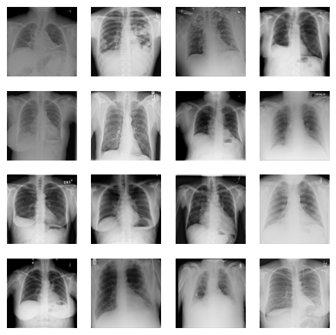

```python
plt.style.use('default')
fig=plt.figure(figsize=(6, 6))
columns = 4; rows = 4
for i in range(1, columns*rows +1):
    fig.add_subplot(rows, columns, i)
    draw(parsed[not_normal['patientId'].unique()[i]])
```

**Contrast of Classes**

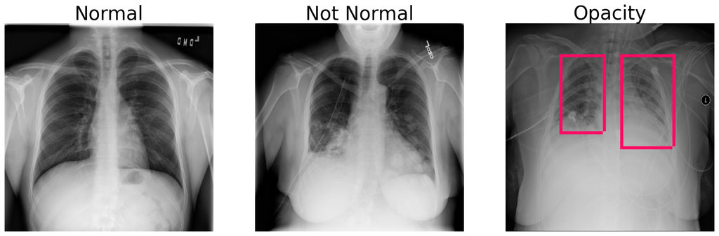

```python
fig=plt.figure(figsize=(20, 10))
columns = 3; rows = 1
fig.add_subplot(rows, columns, 1).set_title("Normal", fontsize=30)
draw(parsed[normal['patientId'].unique()[0]])
fig.add_subplot(rows, columns, 2).set_title("Not Normal", fontsize=30)
# ax2.set_title("Not Normal", fontsize=30)
draw(parsed[not_normal['patientId'].unique()[0]])
fig.add_subplot(rows, columns, 3).set_title("Opacity", fontsize=30)
# ax3.set_title("Opacity", fontsize=30)
draw(parsed[opacity['patientId'].unique()[0]])
```

```python
dicom_df=merge_train_df
dicom_df.shape
```

```
(30227, 7)
```

**Extract meta information from DICOM and add to datasets**

```python
from tqdm import tqdm
def process_dicom_data(data_df):
    for n, pid in tqdm(enumerate(data_df['patientId'].unique())):
        dcm_file = '/content/drive/My Drive/GL_Capstone/stage_2_train_images/%s.dcm' % pid
        dcm_data = dcm.read_file(dcm_file)
        idx = (data_df['patientId']==dcm_data.PatientID)
        data_df.loc[idx,'Modality'] = dcm_data.Modality
        data_df.loc[idx,'PatientAge'] = pd.to_numeric(dcm_data.PatientAge)
        data_df.loc[idx,'PatientSex'] = dcm_data.PatientSex
        data_df.loc[idx,'BodyPartExamined'] = dcm_data.BodyPartExamined
        data_df.loc[idx,'ViewPosition'] = dcm_data.ViewPosition
```

```python
dicom_df = process_dicom_data(dicom_df)
```

```
155it [00:33,  2.73it/s]
```

[output not shown]

# **5. Modelling**

```python
import os
import csv
import random
import pydicom
import numpy as np
import pandas as pd
from skimage import measure
from skimage.transform import resize

import tensorflow as tf
from tensorflow import keras
```

**Load opacity locations**

```python
opacity_locations = {}
# load table
with open(os.path.join('/content/drive/My Drive/GL_Capstone/stage_2_train_labels.csv'), mode='r') as infile:
    # open reader
    reader = csv.reader(infile)
    # skip header
    next(reader, None)
    # loop through rows
    for rows in reader:
        # retrieve information
        filename = rows[0]
        location = rows[1:5]
        lungopacity = rows[5]
        # if row contains lungopacity add label to dictionary
        # which contains a list of lungopacity locations per filename
        if lungopacity == '1':
            # convert string to float to int
            location = [int(float(i)) for i in location]
            # save lungopacity location in dictionary
            if filename in opacity_locations:
                opacity_locations[filename].append(location)
            else:
                opacity_locations[filename] = [location]
```

**Load File names**

```python
folder = '/content/drive/My Drive/GL_Capstone/stage_2_train_images'
filenames = os.listdir(folder)
random.shuffle(filenames)
# split into train and validation filenames
n_valid_samples = 2560
train_filenames = filenames[n_valid_samples:]
valid_filenames = filenames[:n_valid_samples]
print('n file samples:', len(filenames))
print('n train samples:', len(train_filenames))
print('n valid samples:', len(valid_filenames))
n_train_samples = len(filenames) - n_valid_samples
```

```
n file samples: 26684
n train samples: 24124
n valid samples: 2560
```

Image segmentation

**Image segmentation** creates a pixel-wise mask for each object in the image. This technique gives us a far more granular understanding of the object(s) in the image.

The dataset is too large to fit into memory, so we need to create a generator class that loads data on the fly.

**I/p**: filenames, batch_size and other parameters.

**O/p**: a random batch of numpy images and numpy masks.

**Augmentation**: Augmentation technique is done on images and masks as follows.

**Define generator class**

```python
class generator(keras.utils.Sequence):

    def __init__(self, folder, filenames, opacity_locations=None, batch_size=32, image_size=320, shuffle=True, augment=False, predict=False):
        self.folder = folder
        self.filenames = filenames
        self.opacity_locations = opacity_locations
        self.batch_size = batch_size
        self.image_size = image_size
        self.shuffle = shuffle
        self.augment = augment
        self.predict = predict
        self.on_epoch_end()

    def __load__(self, filename):
        # load dicom file as numpy array
        img = pydicom.dcmread(os.path.join(self.folder, filename)).pixel_array
        # create empty mask
        msk = np.zeros(img.shape)
        # get filename without extension
        filename = filename.split('.')[0]
        # if image contains lung opacity
        if filename in opacity_locations:
            # loop through opacity
            for location in opacity_locations[filename]:
                # add 1's at the location of the lung opacity
                x, y, w, h = location
                msk[y:y+h, x:x+w] = 1
        # if augment then horizontal flip half the time
        if self.augment and random.random() > 0.5:
            img = np.fliplr(img)
            msk = np.fliplr(msk)
        # resize both image and mask
        img = resize(img, (self.image_size, self.image_size), mode='reflect')
        msk = resize(msk, (self.image_size, self.image_size), mode='reflect') > 0.5
        # add trailing channel dimension
        img = np.expand_dims(img, -1)
        msk = np.expand_dims(msk, -1)
        return img, msk

    def __loadpredict__(self, filename):
        # load dicom file as numpy array
        img = pydicom.dcmread(os.path.join(self.folder, filename)).pixel_array
        # resize image
        img = resize(img, (self.image_size, self.image_size), mode='reflect')
        # add trailing channel dimension
        img = np.expand_dims(img, -1)
        return img

    def __getitem__(self, index):
        # select batch
        filenames = self.filenames[index*self.batch_size:(index+1)*self.batch_size]
        # predict mode: return images and filenames
        if self.predict:
            # load files
            imgs = [self.__loadpredict__(filename) for filename in filenames]
            # create numpy batch
            imgs = np.array(imgs)
            return imgs, filenames
        # train mode: return images and masks
        else:
            # load files
            items = [self.__load__(filename) for filename in filenames]
            # unzip images and masks
            imgs, msks = zip(*items)
            # create numpy batch
            imgs = np.array(imgs)
            msks = np.array(msks)
            return imgs, msks

    def on_epoch_end(self):
        if self.shuffle:
            random.shuffle(self.filenames)

    def __len__(self):
        if self.predict:
            # return everything
            return int(np.ceil(len(self.filenames) / self.batch_size))
        else:
            # return full batches only
            return int(len(self.filenames) / self.batch_size)
```

**Split Train and Validation generator data**

```python
BATCH_SIZE = 32
IMAGE_SIZE = 128
SHUFFLE_BUFFER_SIZE=1000
```

```python
# Create Train and Validation generators
folder = '/content/drive/My Drive/GL_Capstone/stage_2_train_images'
train_gen = generator(folder, train_filenames, opacity_locations, batch_size=BATCH_SIZE, image_size=IMAGE_SIZE, shuffle=True, augment=False, predict=False)
valid_gen = generator(folder, valid_filenames, opacity_locations, batch_size=BATCH_SIZE, image_size=IMAGE_SIZE, shuffle=False, predict=False)
```

```python
import keras
from keras.models import Sequential
from keras.layers import Conv2D, UpSampling2D, MaxPooling2D
```

**Build Basic Model**

```python
model = Sequential()
model.add(keras.layers.Conv2D(1, kernel_size=3, input_shape=(128, 128, 1), padding='same', use_bias=False))
model.add(keras.layers.Conv2D(8, kernel_size=3, padding='same', activation='relu'))
model.add(keras.layers.BatchNormalization(momentum=0.9))
model.add(keras.layers.Dropout(0.2))
model.add(keras.layers.Conv2D(16, kernel_size=3, padding='same', activation='relu'))
model.add(keras.layers.BatchNormalization(momentum=0.9))
model.add(keras.layers.Dropout(0.2))
model.add(keras.layers.Conv2D(32, kernel_size=3, padding='same', activation='relu'))
model.add(keras.layers.BatchNormalization(momentum=0.9))
model.add(keras.layers.Dropout(0.2))
model.add(keras.layers.Conv2D(64, kernel_size=3, padding="same", activation='relu'))
model.add(keras.layers.BatchNormalization(momentum=0.9))
model.add(keras.layers.Dropout(0.2))
model.add(keras.layers.Conv2D(128, kernel_size=3, padding="same", activation='relu'))
model.add(keras.layers.BatchNormalization(momentum=0.9))
model.add(keras.layers.Dropout(0.2))
model.add(keras.layers.Conv2D(64, kernel_size=3, padding="same", activation='relu'))
model.add(keras.layers.BatchNormalization(momentum=0.9))
model.add(keras.layers.Dropout(0.2))
model.add(keras.layers.Conv2D(32, kernel_size=3, padding='same', activation='relu'))
model.add(keras.layers.BatchNormalization(momentum=0.9))
model.add(keras.layers.Dropout(0.2))
model.add(keras.layers.Conv2D(16, kernel_size=3, padding='same', activation='relu'))
model.add(keras.layers.BatchNormalization(momentum=0.9))
model.add(keras.layers.Dropout(0.2))
model.add(keras.layers.Conv2D(8, kernel_size=3, padding='same', activation='relu'))
model.add(keras.layers.BatchNormalization(momentum=0.9))
model.add(keras.layers.Dropout(0.5))
model.add(keras.layers.Dense(1, activation='sigmoid'))
```

```python
print(model.summary())
```

```
Model: "sequential_2"
_________________________________________________________________
Layer (type)                 Output Shape              Param #
=================================================================
conv2d_11 (Conv2D)           (None, 128, 128, 1)       9
_________________________________________________________________
conv2d_12 (Conv2D)           (None, 128, 128, 8)       80
_________________________________________________________________
batch_normalization_10 (Batc (None, 128, 128, 8)       32
_________________________________________________________________
dropout_10 (Dropout)         (None, 128, 128, 8)       0
_________________________________________________________________
conv2d_13 (Conv2D)           (None, 128, 128, 16)      1168
_________________________________________________________________
batch_normalization_11 (Batc (None, 128, 128, 16)      64
_________________________________________________________________
dropout_11 (Dropout)         (None, 128, 128, 16)      0
_________________________________________________________________
conv2d_14 (Conv2D)           (None, 128, 128, 32)      4640
_________________________________________________________________
batch_normalization_12 (Batc (None, 128, 128, 32)      128
_________________________________________________________________
dropout_12 (Dropout)         (None, 128, 128, 32)      0
_________________________________________________________________
conv2d_15 (Conv2D)           (None, 128, 128, 64)      18496
_________________________________________________________________
batch_normalization_13 (Batc (None, 128, 128, 64)      256
_________________________________________________________________
dropout_13 (Dropout)         (None, 128, 128, 64)      0
_________________________________________________________________
conv2d_16 (Conv2D)           (None, 128, 128, 128)     73856
_________________________________________________________________
batch_normalization_14 (Batc (None, 128, 128, 128)     512
_________________________________________________________________
dropout_14 (Dropout)         (None, 128, 128, 128)     0
_________________________________________________________________
conv2d_17 (Conv2D)           (None, 128, 128, 64)      73792
_________________________________________________________________
batch_normalization_15 (Batc (None, 128, 128, 64)      256
_________________________________________________________________
```

[output cut: 12 more lines]

```
dropout_17 (Dropout)         (None, 128, 128, 16)      0
_________________________________________________________________
conv2d_20 (Conv2D)           (None, 128, 128, 8)       1160
_________________________________________________________________
batch_normalization_18 (Batc (None, 128, 128, 8)       32
_________________________________________________________________
dropout_18 (Dropout)         (None, 128, 128, 8)       0
_________________________________________________________________
dense_2 (Dense)              (None, 128, 128, 1)       9
=================================================================
Total params: 197,770
Trainable params: 197,034
Non-trainable params: 736
_________________________________________________________________
None
```

**Compilation of basic model**

```python
model.compile(optimizer='adam',
              loss='binary_crossentropy',
              metrics=['accuracy'])
```

```python
history = model.fit_generator(train_gen, validation_data=valid_gen, epochs=2, steps_per_epoch =10, shuffle=True)
```

**Evaluation**

```python
model.evaluate(valid_gen)
```

```
[0.61436927318573, 0.9648578763008118]
```

- Validation Accuracy: **96.49%**
- Validation Loss: **0.61**
- Epochs: **2**

# **6. Transfer Learning**

**Residual-Network**

This is a Microsoft’s model, won the 2016 ImageNet competition with 96.4 % accuracy. It is well-known due to its depth (152 layers) and the introduction of residual blocks. The residual blocks address the problem of training a really deep architecture by introducing identity skip connections so that layers can copy their inputs to the next layer. We are using a pre-trained model of ResNet50 for Lung Opacity Detection System.

```python
!pip install opencv-python
import cv2
keras = tf.compat.v1.keras
#Sequence = keras.utils.Sequence
```

**Define generatortransfer class**

```python
class generatortransfer(keras.utils.Sequence):

    def __init__(self, folder, filenames, opacity_locations=None, batch_size=32, image_size=320, shuffle=True, augment=False, predict=False):
        self.folder = folder
        self.filenames = filenames
        self.opacity_locations = opacity_locations
        self.batch_size = batch_size
        self.image_size = image_size
        self.shuffle = shuffle
        self.augment = augment
        self.predict = predict
        self.on_epoch_end()

    def __load__(self, filename):
        # load dicom file as numpy array
        img = pydicom.dcmread(os.path.join(self.folder, filename)).pixel_array
        # create empty mask
        msk = np.zeros(img.shape)
        # get filename without extension
        filename = filename.split('.')[0]
        # if image contains lung opacity
        if filename in opacity_locations:
            # loop through opacity
            for location in opacity_locations[filename]:
                # add 1's at the location of the lung opacity
                x, y, w, h = location
                msk[y:y+h, x:x+w] = 1
        # if augment then horizontal flip half the time
        if self.augment and random.random() > 0.5:
            img = np.fliplr(img)
            msk = np.fliplr(msk)
        # resize both image and mask
        #img = resize(img, (self.image_size, self.image_size), mode='reflect')
        msk = resize(msk, (self.image_size, self.image_size), mode='reflect') > 0.5
        # add trailing channel dimension
        msk = np.expand_dims(msk, -1)
         #Converting Image from GrayScale to RGB
        if len(img.shape) != 3 or img.shape[2] != 3:
            img = np.stack((img,) * 3, -1)
            img = cv2.resize(img, dsize=(self.image_size, self.image_size), interpolation=cv2.INTER_CUBIC)
        return img, msk

    def __loadpredict__(self, filename):
        # load dicom file as numpy array
        img = pydicom.dcmread(os.path.join(self.folder, filename)).pixel_array
        # resize image
        #img = resize(img, (self.image_size, self.image_size), mode='reflect')
        #Converting Image from GrayScale to RGB
        if len(img.shape) != 3 or img.shape[2] != 3:
          img = np.stack((img,) * 3, -1)
          img = cv2.resize(img, dsize=(self.image_size, self.image_size), interpolation=cv2.INTER_CUBIC)
        return img

    def __getitem__(self, index):
        # select batch
        filenames = self.filenames[index*self.batch_size:(index+1)*self.batch_size]
        # predict mode: return images and filenames
        if self.predict:
            # load files
            imgs = [self.__loadpredict__(filename) for filename in filenames]
            # create numpy batch
            imgs = np.array(imgs)
            return imgs, filenames
        # train mode: return images and masks
        else:
            # load files
            items = [self.__load__(filename) for filename in filenames]
            # unzip images and masks
            imgs, msks = zip(*items)
            # create numpy batch
            imgs = np.array(imgs)
            msks = np.array(msks)
            return imgs, msks

    def on_epoch_end(self):
        if self.shuffle:
            random.shuffle(self.filenames)

    def __len__(self):
        if self.predict:
            # return everything
            return int(np.ceil(len(self.filenames) / self.batch_size))
        else:
            # return full batches only
            return int(len(self.filenames) / self.batch_size)
```

```python
BATCH_SIZE = 32
IMAGE_SIZE = 128
SHUFFLE_BUFFER_SIZE=1000
```

**Split Train and Validation generator data for TL**

```python
# create train and validation generators
folder = '/content/drive/My Drive/GL_Capstone/stage_2_train_images'
train_trans = generatortransfer(folder, train_filenames, opacity_locations, batch_size=BATCH_SIZE, image_size=IMAGE_SIZE, shuffle=True, augment=False, predict=False)
valid_trans = generatortransfer(folder, valid_filenames, opacity_locations, batch_size=BATCH_SIZE, image_size=IMAGE_SIZE, shuffle=False, predict=False)
```

```python
#from tensorflow.keras.applications.mobilenet import MobileNet
from tensorflow.keras.applications.resnet50 import ResNet50
from tensorflow.keras.layers import Concatenate, UpSampling2D, Conv2D, Reshape
from tensorflow.keras.models import Model
```

**Load ResNet50 pre-trained model**

```python
# Load pre-trained ResNet50
base_model = ResNet50(input_shape=(IMAGE_SIZE, IMAGE_SIZE, 3), weights='imagenet', include_top=False)
```

```
Downloading data from https://storage.googleapis.com/tensorflow/keras-applications/resnet/resnet50_weights_tf_dim_ordering_tf_kernels_notop.h5
```

```python
base_model.summary()
```

```
Model: "resnet50"
__________________________________________________________________________________________________
Layer (type)                    Output Shape         Param #     Connected to
==================================================================================================
input_1 (InputLayer)            [(None, 128, 128, 3) 0
__________________________________________________________________________________________________
conv1_pad (ZeroPadding2D)       (None, 134, 134, 3)  0           input_1[0][0]
__________________________________________________________________________________________________
conv1_conv (Conv2D)             (None, 64, 64, 64)   9472        conv1_pad[0][0]
__________________________________________________________________________________________________
conv1_bn (BatchNormalization)   (None, 64, 64, 64)   256         conv1_conv[0][0]
__________________________________________________________________________________________________
conv1_relu (Activation)         (None, 64, 64, 64)   0           conv1_bn[0][0]
__________________________________________________________________________________________________
pool1_pad (ZeroPadding2D)       (None, 66, 66, 64)   0           conv1_relu[0][0]
__________________________________________________________________________________________________
pool1_pool (MaxPooling2D)       (None, 32, 32, 64)   0           pool1_pad[0][0]
__________________________________________________________________________________________________
conv2_block1_1_conv (Conv2D)    (None, 32, 32, 64)   4160        pool1_pool[0][0]
__________________________________________________________________________________________________
conv2_block1_1_bn (BatchNormali (None, 32, 32, 64)   256         conv2_block1_1_conv[0][0]
__________________________________________________________________________________________________
conv2_block1_1_relu (Activation (None, 32, 32, 64)   0           conv2_block1_1_bn[0][0]
__________________________________________________________________________________________________
conv2_block1_2_conv (Conv2D)    (None, 32, 32, 64)   36928       conv2_block1_1_relu[0][0]
__________________________________________________________________________________________________
conv2_block1_2_bn (BatchNormali (None, 32, 32, 64)   256         conv2_block1_2_conv[0][0]
__________________________________________________________________________________________________
conv2_block1_2_relu (Activation (None, 32, 32, 64)   0           conv2_block1_2_bn[0][0]
__________________________________________________________________________________________________
conv2_block1_0_conv (Conv2D)    (None, 32, 32, 256)  16640       pool1_pool[0][0]
__________________________________________________________________________________________________
conv2_block1_3_conv (Conv2D)    (None, 32, 32, 256)  16640       conv2_block1_2_relu[0][0]
__________________________________________________________________________________________________
conv2_block1_0_bn (BatchNormali (None, 32, 32, 256)  1024        conv2_block1_0_conv[0][0]
__________________________________________________________________________________________________
conv2_block1_3_bn (BatchNormali (None, 32, 32, 256)  1024        conv2_block1_3_conv[0][0]
__________________________________________________________________________________________________
conv2_block1_add (Add)          (None, 32, 32, 256)  0           conv2_block1_0_bn[0][0]
                                                                 conv2_block1_3_bn[0][0]
```

[output cut: 319 more lines]

```
conv5_block3_2_relu (Activation (None, 4, 4, 512)    0           conv5_block3_2_bn[0][0]
__________________________________________________________________________________________________
conv5_block3_3_conv (Conv2D)    (None, 4, 4, 2048)   1050624     conv5_block3_2_relu[0][0]
__________________________________________________________________________________________________
conv5_block3_3_bn (BatchNormali (None, 4, 4, 2048)   8192        conv5_block3_3_conv[0][0]
__________________________________________________________________________________________________
conv5_block3_add (Add)          (None, 4, 4, 2048)   0           conv5_block2_out[0][0]
                                                                 conv5_block3_3_bn[0][0]
__________________________________________________________________________________________________
conv5_block3_out (Activation)   (None, 4, 4, 2048)   0           conv5_block3_add[0][0]
==================================================================================================
Total params: 23,587,712
Trainable params: 23,534,592
Non-trainable params: 53,120
__________________________________________________________________________________________________
```

**Initialize Parameters**

```python
img_width=8
img_height=8
kernel =3
input_shape = (img_width, img_height, 3)
```

**Adding further layers**

```python
import keras
from keras.datasets import mnist
from keras.models import Sequential
from keras.layers import Conv2D, UpSampling2D, MaxPooling2D
inp_conv = tf.keras.layers.Conv2D(1024, (2, 2), activation='relu', padding='same', input_shape=input_shape)
upsample1= tf.keras.layers.UpSampling2D()
h1 = tf.keras.layers.Conv2D(512, (2, 2), activation='relu', padding='same')
upsample2 = tf.keras.layers.UpSampling2D()
h2 = tf.keras.layers.Conv2D(256, (2, 2), activation='relu', padding='same')
upsample3= tf.keras.layers.UpSampling2D()
h3 = tf.keras.layers.Conv2D(64, (2, 2), activation='relu', padding='same')
upsample4 = tf.keras.layers.UpSampling2D()
h4 = tf.keras.layers.Conv2D(32, (2, 2), activation='relu', padding='same')
upsample5 = tf.keras.layers.UpSampling2D()
final_conv = tf.keras.layers.Conv2D(3, (2, 2), activation='sigmoid', padding='same')
```

```python
restrans_model = tf.keras.Sequential([base_model, inp_conv, upsample1, h1, upsample2, h2, upsample3, h3, upsample4, h4, upsample5, final_conv ])
```

```python
restrans_model.summary()
```

```
Model: "sequential"
_________________________________________________________________
Layer (type)                 Output Shape              Param #
=================================================================
resnet50 (Model)             (None, 4, 4, 2048)        23587712
_________________________________________________________________
conv2d (Conv2D)              (None, 4, 4, 1024)        8389632
_________________________________________________________________
up_sampling2d (UpSampling2D) (None, 8, 8, 1024)        0
_________________________________________________________________
conv2d_1 (Conv2D)            (None, 8, 8, 512)         2097664
_________________________________________________________________
up_sampling2d_1 (UpSampling2 (None, 16, 16, 512)       0
_________________________________________________________________
conv2d_2 (Conv2D)            (None, 16, 16, 256)       524544
_________________________________________________________________
up_sampling2d_2 (UpSampling2 (None, 32, 32, 256)       0
_________________________________________________________________
conv2d_3 (Conv2D)            (None, 32, 32, 64)        65600
_________________________________________________________________
up_sampling2d_3 (UpSampling2 (None, 64, 64, 64)        0
_________________________________________________________________
conv2d_4 (Conv2D)            (None, 64, 64, 32)        8224
_________________________________________________________________
up_sampling2d_4 (UpSampling2 (None, 128, 128, 32)      0
_________________________________________________________________
conv2d_5 (Conv2D)            (None, 128, 128, 3)       387
=================================================================
Total params: 34,673,763
Trainable params: 34,620,643
Non-trainable params: 53,120
_________________________________________________________________
```

**Compile TL Model**

```python
restrans_model.compile(optimizer='adam',
              loss='binary_crossentropy',
              metrics=['accuracy'])
```

**Define Callbacks**

```python
from tensorflow.keras.callbacks import EarlyStopping, ModelCheckpoint, ReduceLROnPlateau
## Earlystopping
earlystop = EarlyStopping(monitor='val_loss', patience=2)

## Model Check point
filepath="LungOpacity-{epoch:02d}-{val_accuracy:.2f}.hdf5"
checkpoint = ModelCheckpoint(filepath, monitor='val_loss', verbose=1, save_best_only=True, mode='min', save_weights_only = True)

## Reduce learning rate when metric has stopped improving
reduceLROnPlat = ReduceLROnPlateau(monitor='val_loss', factor=0.8,
                                   patience=10, verbose=1, mode='auto',
                                   epsilon=0.0001, cooldown=5, min_lr=0.0001)
```

```
WARNING:tensorflow:`epsilon` argument is deprecated and will be removed, use `min_delta` instead.
```

**Fitting TL Model**

```python
history = restrans_model.fit(train_trans, validation_data=valid_trans, callbacks = [earlystop, checkpoint, reduceLROnPlat],
                             epochs=10, steps_per_epoch =10, shuffle=True)
```

```
Epoch 00001: val_loss improved from inf to 1668.00562, saving model to LungOpacity-01-0.01.hdf5
Epoch 00002: val_loss improved from 1668.00562 to 36.74990, saving model to LungOpacity-02-0.31.hdf5
Epoch 00003: val_loss improved from 36.74990 to 6.29850, saving model to LungOpacity-03-0.30.hdf5
Epoch 00004: val_loss improved from 6.29850 to 1.22749, saving model to LungOpacity-04-0.41.hdf5
Epoch 00005: val_loss improved from 1.22749 to 1.08243, saving model to LungOpacity-05-0.43.hdf5
Epoch 00006: val_loss improved from 1.08243 to 0.42711, saving model to LungOpacity-06-0.15.hdf5
Epoch 00007: val_loss improved from 0.42711 to 0.20344, saving model to LungOpacity-07-0.18.hdf5
Epoch 00008: val_loss did not improve from 0.20344
Epoch 00009: val_loss did not improve from 0.20344
```

**Evaluation**

```python
restrans_model.evaluate(valid_trans)
```

```
[0.24121466279029846, 0.5673017501831055]
```

Before Hyper Parameter Tuning:

- Epochs: **9**
- Validation Loss: **0.2412**
- Validation Accuracy: **56.73%**

# **7. Hyper Parameter Tuning**

**Define Metrics**

**Mean IOU**

```python
# mean iou as a metric
def mean_iou(y_true, y_pred):
    y_pred = tf.round(y_pred)
    intersect = tf.reduce_sum(y_true * y_pred, axis=[1, 2, 3])
    union = tf.reduce_sum(y_true, axis=[1, 2, 3]) + tf.reduce_sum(y_pred, axis=[1, 2, 3])
    smooth = tf.ones(tf.shape(intersect))
    return tf.reduce_mean((intersect + smooth) / (union - intersect + smooth))
```

```python
img_width=8
img_height=8
kernel =3
input_shape = (img_width, img_height, 3)
```

```python
import keras
from keras.datasets import mnist
from keras.models import Sequential
from keras.layers import Conv2D, UpSampling2D, MaxPooling2D
inp_conv = tf.keras.layers.Conv2D(1024, (2, 2), activation='relu', padding='same', input_shape=input_shape)
upsample1= tf.keras.layers.UpSampling2D()
h1 = tf.keras.layers.Conv2D(512, (2, 2), activation='relu', padding='same')
upsample2 = tf.keras.layers.UpSampling2D()
h2 = tf.keras.layers.Conv2D(256, (2, 2), activation='relu', padding='same')
upsample3= tf.keras.layers.UpSampling2D()
h3 = tf.keras.layers.Conv2D(64, (2, 2), activation='relu', padding='same')
upsample4 = tf.keras.layers.UpSampling2D()
h4 = tf.keras.layers.Conv2D(32, (2, 2), activation='relu', padding='same')
upsample5 = tf.keras.layers.UpSampling2D()
final_conv = tf.keras.layers.Conv2D(3, (2, 2), activation='sigmoid', padding='same')
```

```python
tune_model = tf.keras.Sequential([base_model, inp_conv, upsample1, h1, upsample2, h2, upsample3, h3, upsample4, h4, upsample5, final_conv ])
```

```python
tune_model.summary()
```

```
Model: "sequential"
_________________________________________________________________
Layer (type)                 Output Shape              Param #
=================================================================
resnet50 (Model)             (None, 4, 4, 2048)        23587712
_________________________________________________________________
conv2d (Conv2D)              (None, 4, 4, 1024)        8389632
_________________________________________________________________
up_sampling2d (UpSampling2D) (None, 8, 8, 1024)        0
_________________________________________________________________
conv2d_1 (Conv2D)            (None, 8, 8, 512)         2097664
_________________________________________________________________
up_sampling2d_1 (UpSampling2 (None, 16, 16, 512)       0
_________________________________________________________________
conv2d_2 (Conv2D)            (None, 16, 16, 256)       524544
_________________________________________________________________
up_sampling2d_2 (UpSampling2 (None, 32, 32, 256)       0
_________________________________________________________________
conv2d_3 (Conv2D)            (None, 32, 32, 64)        65600
_________________________________________________________________
up_sampling2d_3 (UpSampling2 (None, 64, 64, 64)        0
_________________________________________________________________
conv2d_4 (Conv2D)            (None, 64, 64, 32)        8224
_________________________________________________________________
up_sampling2d_4 (UpSampling2 (None, 128, 128, 32)      0
_________________________________________________________________
conv2d_5 (Conv2D)            (None, 128, 128, 3)       387
=================================================================
Total params: 34,673,763
Trainable params: 34,620,643
Non-trainable params: 53,120
_________________________________________________________________
```

```python
tune_model.compile(optimizer='adam',
              loss='categorical_crossentropy',
              metrics=['accuracy',mean_iou])
```

```python
history = tune_model.fit(train_trans, validation_data=valid_trans, callbacks = [earlystop, checkpoint, reduceLROnPlat],
                             epochs=10, steps_per_epoch =10, shuffle=True)
```

```
Epoch 00001: val_loss improved from inf to 0.09006, saving model to LungOpacity-01-0.99.hdf5
Epoch 00002: val_loss did not improve from 0.09006
Epoch 00003: val_loss did not improve from 0.09006
```

```python
tune_model.evaluate(valid_trans)
```

```
[0.0900564044713974, 0.999998927116394, 0.03165740892291069]
```

After Hyper Parameter Tuning:

- Epochs: **3**
- Validation Loss: **0.0901**
- Validation Accuracy: **99.9998%**
- IOU Mean: **0.0317**

# **8. Plot History**

**1. Accuracy Graph**

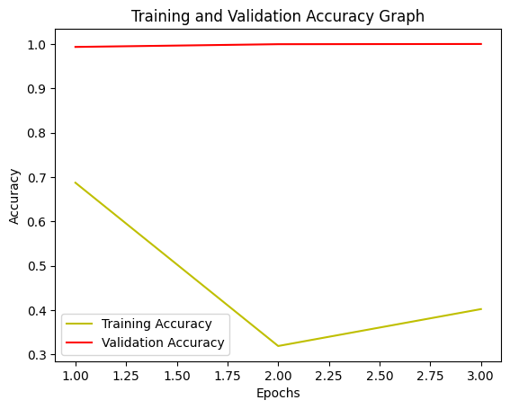

```python
acc = history.history['accuracy']
val_acc = history.history['val_accuracy']
epochs = range(1, len(acc) + 1)
plt.plot(epochs, acc, 'y', label='Training Accuracy')
plt.plot(epochs, val_acc, 'r', label='Validation Accuracy')
plt.title('Training and Validation Accuracy Graph')
plt.xlabel('Epochs')
plt.ylabel('Accuracy')
plt.legend()
plt.show()
```

**2. Loss Graph**

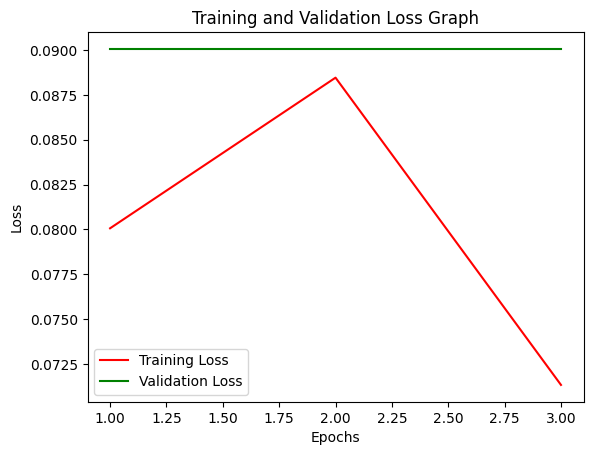

```python
Train_Loss = history.history['loss']
Val_Loss = history.history['val_loss']
Epochs = range(1, len(Train_Loss) + 1)
plt.plot(Epochs, Train_Loss, 'r', label='Training Loss')
plt.plot(Epochs, Val_Loss, 'g', label='Validation Loss')
plt.title('Training and Validation Loss Graph')
plt.xlabel('Epochs')
plt.ylabel('Loss')
plt.legend()
plt.show()
```

**3. Mean IoU Graph**

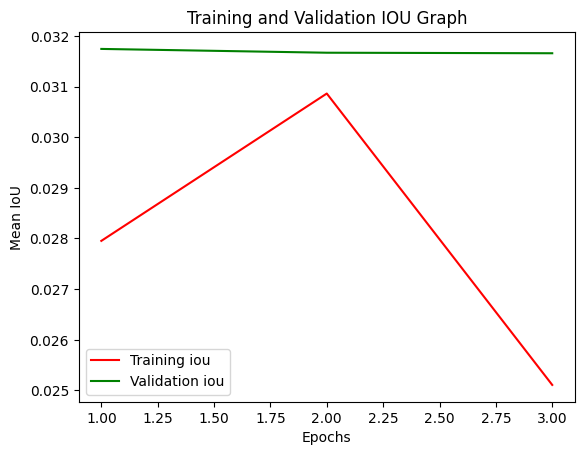

```python
train_iou = history.history['mean_iou']
val_iou = history.history['val_mean_iou']
epochs = range(1, len(train_iou) + 1)
plt.plot(epochs, train_iou, 'r', label='Training iou')
plt.plot(epochs, val_iou, 'g', label='Validation iou')
plt.title('Training and Validation IOU Graph')
plt.xlabel('Epochs')
plt.ylabel('Mean IoU')
plt.legend()
plt.show()
```

# **9. Save Model weights**

```python
from keras.models import model_from_json

# serialize model to JSON
tunemodel_json = tune_model.to_json()

with open("tune_model.json", "w") as json_file:
    json_file.write(tunemodel_json)

# save weights to HDF5
tune_model.save_weights("lungopacity_resnet50_model.h5")
print("Model saved!!")

# when you want to retrieve the model: load json and create model
json_file = open('tune_model.json', 'r')
saved_model = json_file.read()
# close the file as good practice
json_file.close()
#model_from_json = model_from_json(saved_model)
# load weights into new model
#model_from_json.load_weights("model.h5")
#print("Model loaded..")
```

```
Model saved!!
```

**Load Model (using weights)**

```python
tune_model.load_weights('/content/drive/My Drive/GL_Capstone/LungOpacity-01-0.99.hdf5')
```

# **10. Predict Test images**

```python
# load and shuffle filenames
#folder = '../input/stage_2_test_images'
folder = '/content/drive/My Drive/GL_Capstone/stage_2_test_images'
test_filenames = os.listdir(folder)
print('n test samples:', len(test_filenames))

# create test generator with predict flag set to True
test_gen = generatortransfer(folder, test_filenames, None, batch_size=16, image_size=IMAGE_SIZE, shuffle=False, predict=True)

# create submission dictionary
submission_dict = {}
# loop through testset
for imgs, filenames in tqdm(test_gen):
    # predict batch of images
    preds = tune_model.predict(imgs)
    # loop through batch
    for pred, filename in zip(preds, filenames):
        # resize predicted mask
        pred = resize(pred, (1024, 1024), mode='reflect')
        # threshold predicted mask
        comp = pred[:, :, 0] > 0.5
        # apply connected components
        comp = measure.label(comp)
        # apply bounding boxes
        predictionString = ''
        for region in measure.regionprops(comp):
            # retrieve x, y, height and width
            y, x, y2, x2 = region.bbox
            height = y2 - y
            width = x2 - x
            # proxy for confidence score
            conf = np.mean(pred[y:y+height, x:x+width])
            # add to predictionString
            predictionString += str(conf) + '' + str(x) + ' ' + str(y) + ' ' + str(width) + ' ' + str(height) + ' '
        # add filename and predictionString to dictionary
        filename = filename.split('.')[0]
        submission_dict[filename] = predictionString
    # stop if we've got them all
    if len(submission_dict) >= len(test_filenames):
        break

print("Done predicting...")
```

```
n test samples: 3000
```

```
Done predicting...
```

```python
# save dictionary as csv file
sub = pd.DataFrame.from_dict(submission_dict,orient='index')
sub.index.names = ['patientId']
sub.columns = ['PredictionString']
sub.to_csv('/content/drive/My Drive/GL_Capstone/submission_confidence_resnet_results.csv')
```